# Analyse de durées de vie

Jiménez Jiménez Marisol

2023-02-28

### Présentation du cas à examiner

De 1962 à 1969, plusieurs patients atteint de cirrhose ont rejoint un essai clinique randomisé dont le but était d’étudier l’effet de traitement par un corticïde, le prednisone. Les patients ont été répartis au hasard entre un traitement par prednisone et un traitement placebo. Les durées de survie des patients ont été observées jusqu’en septembre 1974 si bien que les observations sont censurées à droite pour les patients vivants à cette date. Les durées de certains patients ont été égalemet censurés à droite en quittant l’étude avant septembre 1974 en raison des effets secondaires de la prednisone. Nous ne considérons que les données des patients pour lesquels la biopsie initiale pourrait être réévalué. Pour chaque patient les informations suivantes sont données :

- Numéro de patient
- Indicatrice de décès (1) ou de censure (0)
- Durées observées (nombre de jours depuis le début du traitement)
- Traitement : *Prednison* ou *Placebo*
- Sexe : *Female* ou *Male*
- Ascite (quantité de liquide dans la cavité abdominale au début du traitement : *none*, *Little* ou *moderate*)
- Âge au début de traitement
- Prothrombine (indice de la capacité de coagulation du sang), mesuré au début du traitement et donné en % de la normale

## Objectif du projet

Effectuer une analyse statistique complète du jeu de données en utilisant, de manière pertinente et appropriée, tout ce qui a été vu en cours : représentations graphiques, tableaux synthétiques, modèle(s) paramétrique(s), méthode(s) non-paramétriques, modèle(s) semi-paramétrique(s), méthode(s) de machine learning, etc

```r
cat("Dimension du data frame : ",dim(my_data))
```

```
## Dimension du data frame :  439 8
```

```r
head(my_data)
```

```
##   Id.Patient Death ObsTime Treatment    Sex Ascites Age Prothrombin
## 1        251     0    1897   Placebo Female    None  58         100
## 2        266     0    1156 Prednison Female    None  43          90
## 3        553     1    1290 Prednison Female  Little  58          89
## 4         15     1     203   Placebo   Male    None  64          62
## 5        318     0    2969   Placebo   Male    None  43          80
## 6        264     0    3346   Placebo   Male    None  41          69
```

Le but est d’étudier l’effet de traitement par prednisone, la durée d’intérêt ici est alors le décès, on aura reconnu une situation de censure à droite (on n’observe pas le décès après septembre 1974 et nous ne savons pas non plus ce qui arrive aux patients qui abandonnent l’étude.) Pour le moment, nous allons utiliser : la variable *ObsTime* les nombre de jours depuis le début du traitement, la variable *Death* qui indique si’l s’agit d’un décè ou d’une censure et l’âge du début du traitement.

## Modèles paramétriques

La fonction survreg nous permetra d’ajuster un modèle paramétrique de vie accélérée en prendre en compte les durées censurées. Parmi les lois classiques que nous pouvons utiliser pour ajuster le modèle, nous utiliserons celle de Weibull.

Nous allons d’abord séparer la population entre les patients ayant reçu un traitement avec Prednison et ceux ayant reçu un traitement placebo.

### Placebo

On construit ensuite un objet de type survival à l’aide de la fonction Surv où la limite supérieure est *Age + ObsTime*

```r
my_data_placebo=my_data[my_data$Treatment == "Placebo", ]
surv.placebo<-with(my_data_placebo,Surv(Age+ceiling(ObsTime/365),Death))
head(surv.placebo)
```

```
## [1] 64+ 65  52+ 51+ 61+ 49
```

On affiche les premières observations. On obtient alors le résultat où le symbole + indique que la durée est censurée à droite. Le patient 1, par exemple, âgé de 58 ans au début de l’étude, n’était toujours pas décédé à l’âge de 64 ans.

```r
placebo.reg1 <- survreg(surv.placebo~Sex+Prothrombin+Ascites,data=my_data_placebo,dist="weibull")
summary(placebo.reg1)
```

```
##
## Call:
## survreg(formula = surv.placebo ~ Sex + Prothrombin + Ascites,
##     data = my_data_placebo, dist = "weibull")
##                     Value Std. Error      z      p
## (Intercept)      4.207446   0.042695  98.55 <2e-16
## SexMale         -0.059335   0.019835  -2.99 0.0028
## Prothrombin      0.000911   0.000491   1.86 0.0635
## AscitesModerate  0.051490   0.040244   1.28 0.2007
## AscitesNone      0.041432   0.031371   1.32 0.1866
## Log(scale)      -2.193753   0.064370 -34.08 <2e-16
##
## Scale= 0.111
##
## Weibull distribution
## Loglik(model)= -532.1   Loglik(intercept only)= -539.5
##  Chisq= 14.8 on 4 degrees of freedom, p= 0.0051
## Number of Newton-Raphson Iterations: 7
## n= 218
```

Pour valider la signification de chaque variable, nous examinons le résultat de l’analyse anova.

```r
anova(placebo.reg1)
```

```
## Analysis of Deviance Table
##
##  distribution with  link
##
## Response: surv.placebo
##
## Scale estimated
##
## Terms added sequentially (first to last)
##             Df Deviance Resid. Df  -2*LL Pr(>Chi)
## NULL                          216 1078.9
## Sex          1   8.9412       215 1070.0 0.002788 **
## Prothrombin  1   4.0075       214 1066.0 0.045300 *
## Ascites      2   1.8516       212 1064.1 0.396218
## ---
## Signif. codes:  0 '***' 0.001 '**' 0.01 '*' 0.05 '.' 0.1 ' ' 1
```

Nous concluons que pour le traitement placebo, la variable *Ascites* ne contribue pas suffisamment au modèle, en plus la variable *Prohtrombin* est proche des limites pour une valeur *p* acceptable avec un coefficient très faible, de sorte que nous continuons seulement avec la covariable *Sex*.

```r
placebo.reg2 <- survreg(surv.placebo~Sex,data=my_data_placebo,dist="weibull")
summary(placebo.reg2)
```

```
##
## Call:
## survreg(formula = surv.placebo ~ Sex, data = my_data_placebo,
##     dist = "weibull")
##               Value Std. Error      z      p
## (Intercept)  4.3080     0.0149 288.57 <2e-16
## SexMale     -0.0585     0.0196  -2.98 0.0029
## Log(scale)  -2.1834     0.0641 -34.06 <2e-16
##
## Scale= 0.113
##
## Weibull distribution
## Loglik(model)= -535   Loglik(intercept only)= -539.5
##  Chisq= 8.94 on 1 degrees of freedom, p= 0.0028
## Number of Newton-Raphson Iterations: 7
## n= 218
```

### Prednison

Nous répétons le processus pour le traitement avec Prednison, on construit un objet de type survival et commençons par regarder le modèle avec tous les 3 covariables possibles.

```r
my_data_prednison=my_data[my_data$Treatment != "Placebo", ]
surv.prednison<-with(my_data_prednison,Surv(Age+ceiling(ObsTime/365),Death))
prednison.reg1 <- survreg(surv.prednison~Sex+Prothrombin+Ascites,data=my_data_prednison,dist="weibull")
summary(prednison.reg1)
```

```
##
## Call:
## survreg(formula = surv.prednison ~ Sex + Prothrombin + Ascites,
##     data = my_data_prednison, dist = "weibull")
##                     Value Std. Error      z       p
## (Intercept)      4.288693   0.039458 108.69 < 2e-16
## SexMale         -0.077826   0.020670  -3.77 0.00017
## Prothrombin      0.000418   0.000518   0.81 0.41990
## AscitesModerate  0.000968   0.034978   0.03 0.97792
## AscitesNone      0.007131   0.028362   0.25 0.80147
## Log(scale)      -2.188021   0.067649 -32.34 < 2e-16
##
## Scale= 0.112
##
## Weibull distribution
## Loglik(model)= -505.9   Loglik(intercept only)= -513.6
##  Chisq= 15.32 on 4 degrees of freedom, p= 0.0041
## Number of Newton-Raphson Iterations: 7
## n= 221
```

Pour valider la signification de chaque variable, nous examinons le résultat de l’analyse anova.

```r
anova(prednison.reg1)
```

```
## Analysis of Deviance Table
##
##  distribution with  link
##
## Response: surv.prednison
##
## Scale estimated
##
## Terms added sequentially (first to last)
##             Df Deviance Resid. Df  -2*LL  Pr(>Chi)
## NULL                          219 1027.1
## Sex          1  14.1963       218 1012.9 0.0001647 ***
## Prothrombin  1   1.0365       217 1011.9 0.3086375
## Ascites      2   0.0824       215 1011.8 0.9596153
## ---
## Signif. codes:  0 '***' 0.001 '**' 0.01 '*' 0.05 '.' 0.1 ' ' 1
```

Nous concluons que pour le traitement prednison, il y a aussi une seule variable à garder : *Sex*.

```r
prednison.reg2 <- survreg(surv.prednison~as.factor(Sex),data=my_data_prednison,dist="weibull")
summary(prednison.reg2)
```

```
##
## Call:
## survreg(formula = surv.prednison ~ as.factor(Sex), data = my_data_prednison,
##     dist = "weibull")
##                      Value Std. Error     z       p
## (Intercept)         4.3199     0.0162 266.9 < 2e-16
## as.factor(Sex)Male -0.0774     0.0204  -3.8 0.00015
## Log(scale)         -2.1989     0.0665 -33.0 < 2e-16
##
## Scale= 0.111
##
## Weibull distribution
## Loglik(model)= -506.5   Loglik(intercept only)= -513.6
##  Chisq= 14.2 on 1 degrees of freedom, p= 0.00016
## Number of Newton-Raphson Iterations: 7
## n= 221
```

Voyons à quoi ressemblent les fonctions de survie pour les deux traitements segmentés par sexe.

[figure not shown]

```r
sPlacebo  <- flexsurvreg(surv.placebo~as.factor(Sex),dist='weibull',data=my_data_placebo)
plot(sPlacebo,col=c("thistle","lightblue"),main = "Fonctions de survie",xlim = c(30,90))
sPred  <- flexsurvreg(surv.prednison~as.factor(Sex),dist='weibull',data=my_data_prednison)
lines(sPred, col=c("orchid","cyan3"))
legtxt <- c("H Placebo","F Placebo","H Treatment","F Treatment")
legend("topright",pch="_",legend=legtxt,col=couleur,lwd=2)
```

Nous pouvons voir que pour les Hommes, le traitement ne fait practiquement aucune différence sur leur durée de vie, tandis que pour les femmes, nous voyons que le traitement avec Prednison assure une durée de vie plus longue, mais la différence reste encore très faible.

## Modèles non-paramétriques

### Estimateurs Kaplan-Meier et Fleming-Harrington

On va calculer l’estimateur de Kaplan-Meier de la survie ce qui peut être obtenu en utilisant la fonction survfit pour valider choix de la loi de Weibull.

```r
survival_all<-with(my_data,Surv(Age+ceiling(ObsTime/365),Death))
km_estimation <- survfit(survival_all~ Sex + Treatment,data = my_data)
print(km_estimation)
```

```
## Call: survfit(formula = survival_all ~ Sex + Treatment, data = my_data)
##
##                                   n events median 0.95LCL 0.95UCL
## Sex=Female, Treatment=Placebo    92     57     71    69.0      75
## Sex=Female, Treatment=Prednison  90     47     73    67.3      77
## Sex=Male, Treatment=Placebo     126     79     66    64.0      69
## Sex=Male, Treatment=Prednison   131     80     66    65.0      68
```

Nous faisons de même pour l’estimateur Fleming-Harrington

```r
fh_estimation <- survfit(survival_all~ Sex + Treatment,data = my_data,type = "fleming-harrington")
print(fh_estimation)
```

```
## Call: survfit(formula = survival_all ~ Sex + Treatment, data = my_data,
##     type = "fleming-harrington")
##
##                                   n events median 0.95LCL 0.95UCL
## Sex=Female, Treatment=Placebo    92     57     71    69.0      76
## Sex=Female, Treatment=Prednison  90     47     73    67.3      77
## Sex=Male, Treatment=Placebo     126     79     67    64.0      70
## Sex=Male, Treatment=Prednison   131     80     66    65.0      69
```

On valide graphiquement le choix du modèle paramétrique Weibull dans la grapique suivante avec l’estimateur de KM car il est pratiquement identique à ce de Fleming Harrington :

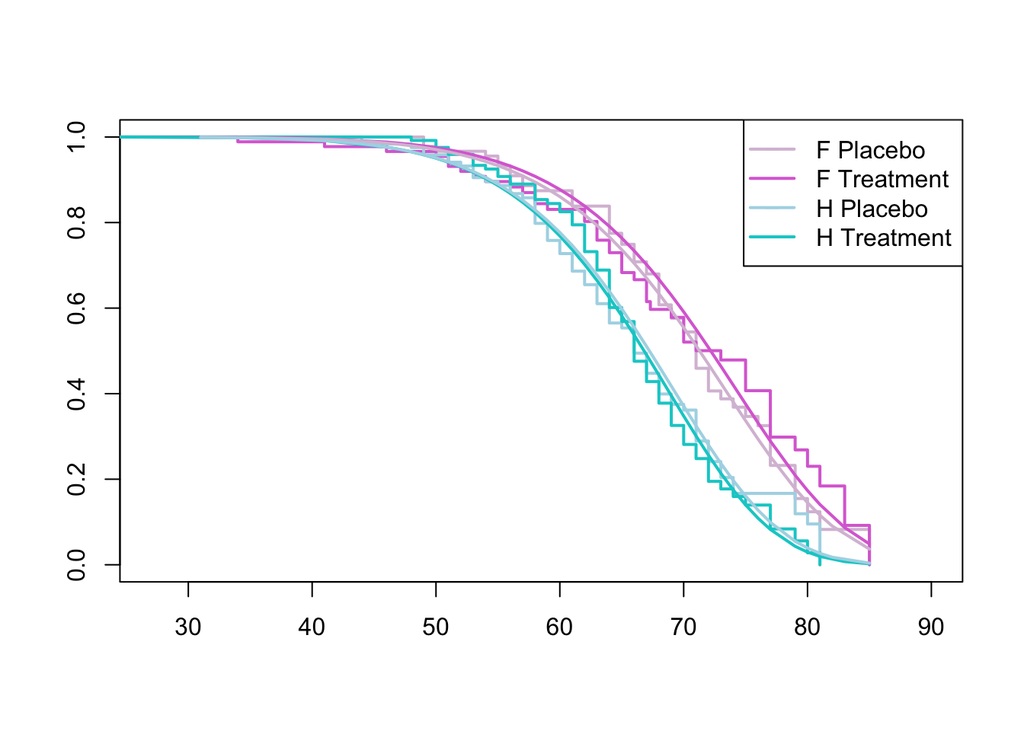

```r
couleur <- c("thistle","orchid","lightblue","cyan3")
plot(km_estimation,mark.time=FALSE,lwd=2,col=couleur,xlim = c(27,90))
lines(sPred, col=c("orchid","cyan3"))
lines(sPlacebo,col=c("thistle","lightblue"))

legtxt <- c("F Placebo","F Treatment","H Placebo","H Treatment")
legend("topright",pch="_",legend=legtxt,col=couleur,lwd=2)
```

### Estimateur de Breslow du risque cumulé

Cet estimateur étant basé sur celui de Kaplan-Meier, on peut le calculer en partant de ce qui précède. Dans ce graphique, nous pouvons également observer que nous avons un risque cumulé plus élevé pour les patients qui ont suivi le traitement avec placebo et en générale pour les hommes.

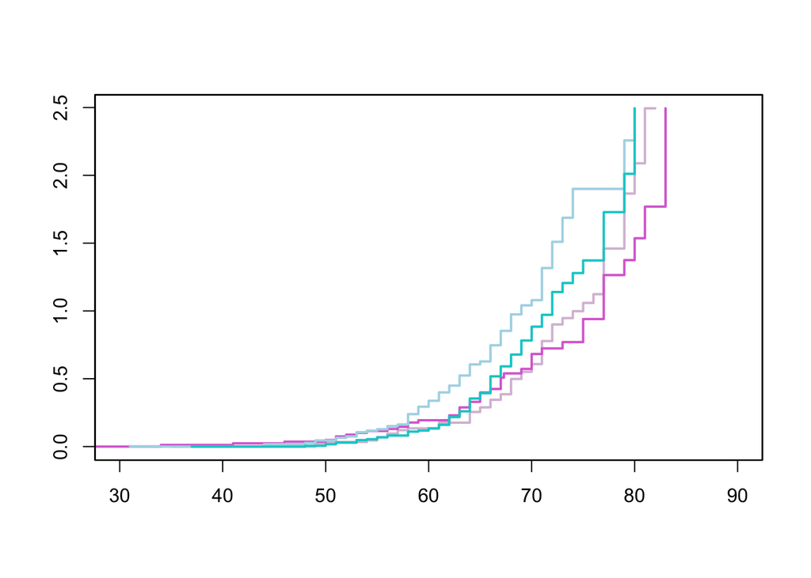

```r
breslow <- cbind(km_estimation$time,-log(km_estimation$surv))
plot(breslow[1:33,],type="s",lwd=2,xlab="",ylab="",col=couleur,xlim = c(30,90))
par(new=TRUE)
plot(breslow[34:71,],type="s",lwd=2,col="orchid",xlim = c(30,90),xaxt = "n",yaxt = "n",xlab="",ylab="")
par(new=TRUE)
plot(breslow[72:107,],type="s",lwd=2,col="lightblue",xlim = c(30,90),xaxt = "n",yaxt = "n",xlab="",ylab="")
par(new=TRUE)
plot(breslow[108:145,],type="s",lwd=2,col="cyan3",xlim = c(30,90),xaxt = "n",yaxt = "n",xlab="",ylab="")
```

## Modèles Semi-paramétriques

### Cox

Modèle avec covariable Sex et Treatment (sans interaction)

```r
fit_coxph_1 <- coxph(survival_all ~ Sex+Treatment, data = my_data)
fit_coxph_1
```

```
## Call:
## coxph(formula = survival_all ~ Sex + Treatment, data = my_data)
##
##                       coef exp(coef) se(coef)      z     p
## SexMale             0.5818    1.7893   0.1295  4.494 7e-06
## TreatmentPrednison -0.0108    0.9892   0.1236 -0.087  0.93
##
## Likelihood ratio test=20.8  on 2 df, p=3.044e-05
## n= 439, number of events= 263
```

Nous voyons que le traitement n’est pas significatif dans notre modèle, donc nous créons maintenant le modèle avec seulement la covariable du sexe en gardant le traitement comme stratification.

Modèle avec covariable Sex et Treatment avec stratification sur Treatment

```r
fit_coxph_2 <- coxph(survival_all ~ Sex+strata(Treatment), data = my_data)
fit_coxph_2
```

```
## Call:
## coxph(formula = survival_all ~ Sex + strata(Treatment), data = my_data)
##
##           coef exp(coef) se(coef)     z        p
## SexMale 0.5671    1.7631   0.1298 4.367 1.26e-05
##
## Likelihood ratio test=19.64  on 1 df, p=9.326e-06
## n= 439, number of events= 263
```

Nous en concluons qu’un homme a 1,76 fois plus de risque de mourir qu’une femme.D’autre part, nous avons également constaté visuellement que les courbes de survie ne sont pas suffisamment différentes pour chaque traitement.

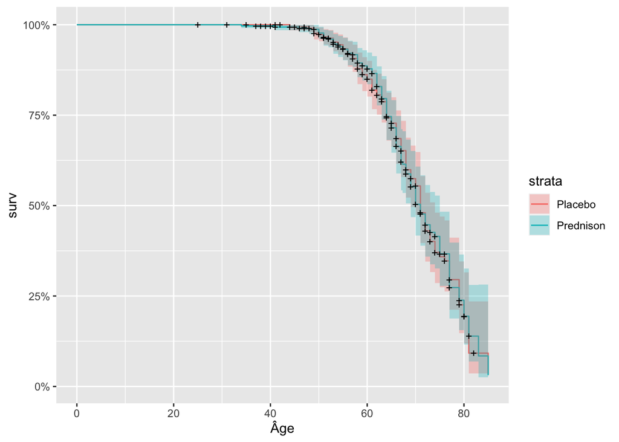

```r
cox_fit_surv <- survfit(fit_coxph_2)
autoplot(cox_fit_surv,xlab = "Âge")
```

### Risques proportionnels

Nous allons maintenant évaluer l’hypothèse des risques proportionnels, en utilisant la fonction ggcoxzph() pour l’analyse graphique.

```r
check_PH <- cox.zph(fit_coxph_2)
check_PH
```

```
##         chisq df    p
## Sex    0.0695  1 0.79
## GLOBAL 0.0695  1 0.79
```

L’hypothèse nulle est associée à la supposition des risques proportionnels. Les résultats de ce test indiquent que l’hypothèse des risques proportionnels n’est pas violée pour la covariable *Sex*, la valeur *p* associée à ce test est de 0,7921, ce qui est supérieur à 0,05, donc ne rejetant pas l’hypothèse des risques proportionnels.

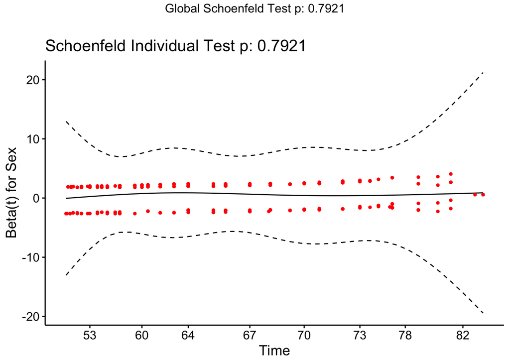

```r
ggcoxzph(check_PH)
```

### Influence des individus

Finalement pour l’influence des individus on analyse les residuales, le graphique suggère qu’aucune des observations n’est pas très influente individuellement, même si certaines des valeurs dfbeta sont grandes par rapport aux autres ; celles qui sont supérieures et inférieures à 0,02 mais elles ne sont que quelques-unes

```r
ggcoxdiagnostics(fit = fit_coxph_2, type = "dfbeta",
linear.predictions = FALSE, ggtheme = theme_bw())
```

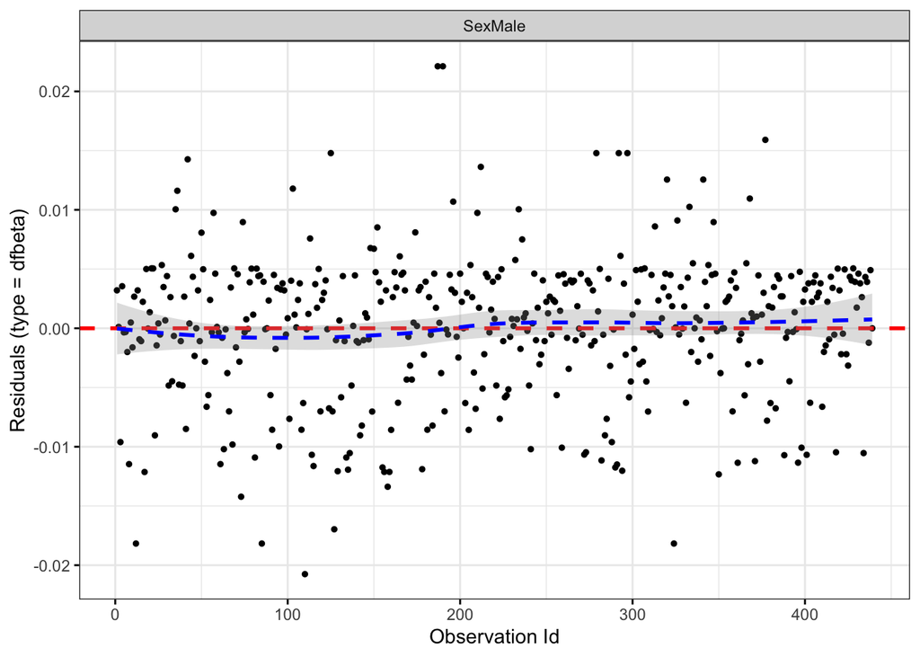

## Modèles ML

### Forêts aléatoires

Pour nos données, nous avons choisi le traitement des forêts aléatoires, nous allons commencer par tracer la fonction de survie pour chaque individu dans l’étude.

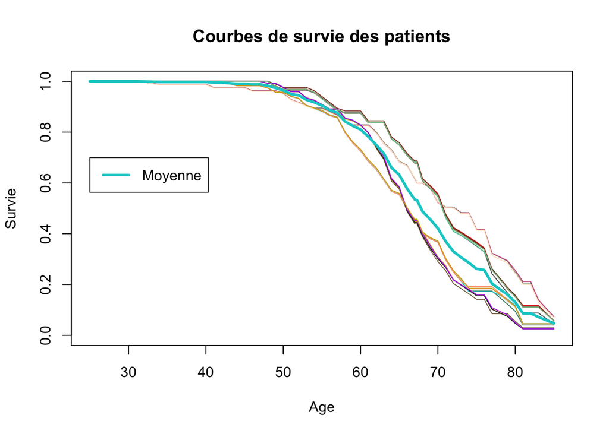

```r
plot(x = r_fit$unique.death.times, y = r_fit$survival[1,],
type = "l",
ylim = c(0,1),
col = "red",
xlab = "Age",
ylab = "Survie",
main = "Courbes de survie des patients")
cols <- colors()
for (n in sample(c(2:dim(my_data)[1]), 20)){
lines(x = r_fit$unique.death.times, y = r_fit$survival[n,], type = "l", col = cols[n])
}
lines(x = death_times, y = avg_prob, lwd = 3,col="cyan3")
legend(25, 0.7, legend = c('Moyenne'), lty=1, cex=1,col="cyan3",lwd=2.5)
```

En examinant le rôle joué par chaque variable, nous constatons une fois de plus que le traitement ne contribue pas à notre modèle.

```r
vi <- data.frame(sort(round(r_fit$variable.importance, 4), decreasing = TRUE))
names(vi) <- "importance"
print(vi)
```

```
##           importance
## Sex           0.0536
## Treatment    -0.0080
```

On garde seulement la covariable *Sex*.

```r
r_fit2 <- ranger(formula = Surv(Age+ceiling(ObsTime/365),Death) ~ Sex,
data = my_data,

importance = "permutation",
splitrule = "extratrees",
verbose = TRUE)
```

## Conclusions

Enfin, nous traçons les modèles (pour le cas sans covariables) obtenus par les méthodes semi-paramétrique, non-paramétrique et de ML. Nous constatons que nos modèles sont effectivement analogues. Nous concluons que, bien que le traitement Predison assure une durée de vie plus longue, il est si léger qu’il n’y a pratiquement aucune différence entre suivre l’un ou l’autre traitement.

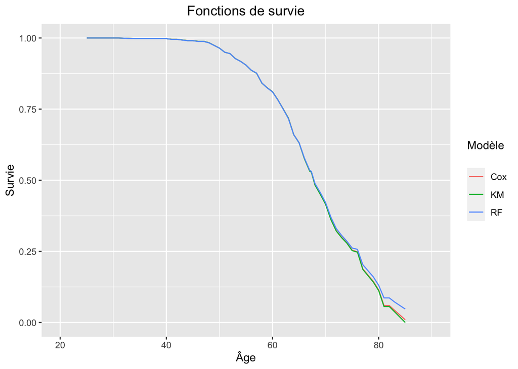

```r
plot_df <- rbind(km_df,cox_df,rf_df)
p <- ggplot(plot_df, aes(x = Time, y = Surv, color = Model))
p + geom_line() + labs(y = "Survie",x = "Âge") +
  ggtitle(label = "Fonctions de survie") +
  ggeasy::easy_center_title() + xlim(20, 90) + labs(color="Modèle\n")
```